# Report

## Extract variables

There are many variables that will not contribute to our research question, so we removed them from our exploration and analyses. Our research question is interested in the relationship of gender pay gaps and gender composition in companies, so we excluded company names and types even though they could be affecting pay gaps under other contexts.

We also excluded types of pays, including bonus and BIK (benefit in kind), since we are only interested one response variables and hourly gaps are the most commonly recognized meausre of comparing wage gaps.

Finally, we also excluded percentage of males since it’s generally a reciprocal of percentage of females. While the percentages do not correlated with each other 100%, for practicality we are only using percentage of female employees as gender composition of companies.

In the end, we examined report years, hourly pay gaps, and gender composition of each company to see which variables are the most sensible to construct a model from.

```r
new_table <- data.frame(Report.Year, Mean.Hourly.Gap, Median.Hourly.Gap, Q1.Female, Q2.Female, Q3.Female, Q4.Female, Percentage.Employees.Female)
```

### Summary Table

```r
st(new_table, digits=6)
```

Summary Statistics

| Variable | N | Mean | Std. Dev. | Min | Pctl. 25 | Pctl. 75 | Max |
| --- | --- | --- | --- | --- | --- | --- | --- |
| Report.Year | 1945 | 2023.03 | 0.821606 | 2022 | 2022 | 2024 | 2024 |
| Mean.Hourly.Gap | 1945 | 11.1995 | 12.5103 | -52.1 | 3.4 | 17.96 | 73 |
| Median.Hourly.Gap | 1945 | 8.12264 | 13.6991 | -120.17 | 0.49 | 15.5 | 100 |
| Q1.Female | 1945 | 50.9757 | 18.237 | 0 | 39.9 | 62.5 | 100 |
| Q2.Female | 1945 | 47.8691 | 20.8093 | 0 | 33 | 61 | 99 |
| Q3.Female | 1945 | 45.5544 | 21.4042 | 0 | 31 | 59 | 100 |
| Q4.Female | 1945 | 39.9133 | 19.4888 | 0 | 26.5 | 50 | 99 |
| Percentage.Employees.Female | 1945 | 46.0782 | 18.4675 | 0 | 34 | 56.25 | 98.25 |

### Distribution of variables

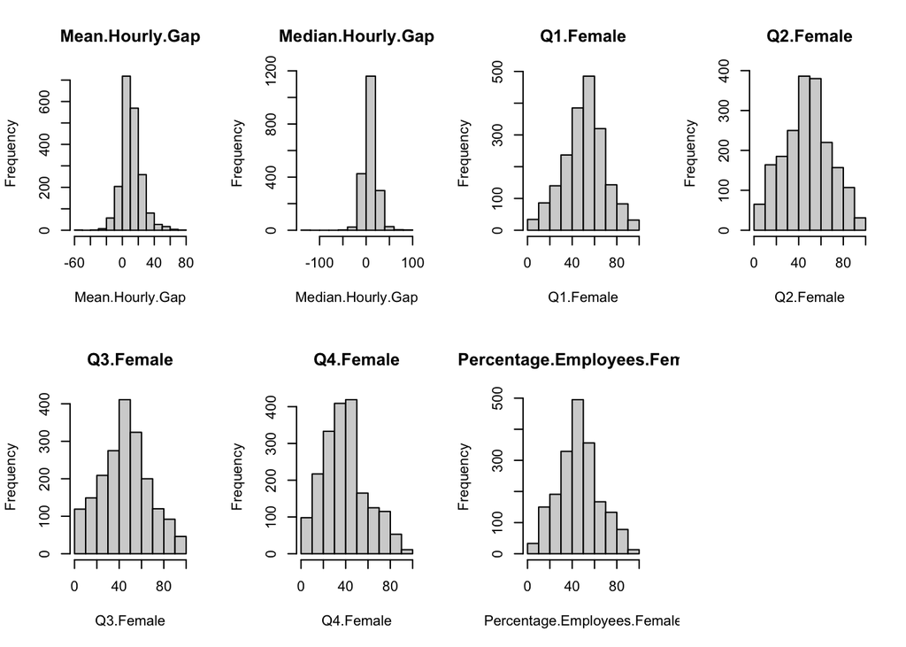

```r
par(mfrow = c(2,4))
for (col in 2:ncol(new_table)){
  hist(new_table[, col], main=colnames(new_table)[col], xlab=colnames(new_table)[col])
}
```

The rationale of reporting median pay gaps is that it is resistant to the influence of outliers. For example, if a company has a high median pay gap but a low mean, this means that only a few female employees are receiving similar pays as their male counterparts while the rest get paid a lot less. However, judging from the summary table and distribution graphs, the mean and median pay gap of the data set share similar distribution, which shows that both measures capture a similar pay gap situation, so it is pratical to just use one of them. Since we’re only interested in one response variable and the mean is a more commonly used measure, we picked mean hourly gap as our response variable for our model.